# 2022-2023 MAC Mens Basketball Season

Alan Morales

2023-04-29

# Introduction

Statistics and sports have an all-encompassing and intertwined history. Throughout history, whether it be player evaluation, sports team assessments, or monetary forecasting, statistical tools assisted this industry. In recent times, sports betting has become a considerable market that intertwines these two areas to a higher degree. One of the targeted variables that all these areas strive to predict are identifying results, who wins and who loses. Result prediction is a classification problem in the statistical world that can easily be implemented as a binary classification problem. This type of problem is a classic case of supervised learning. Supervised learning guides a model by attempting unravel associations between a target, dependent, variable and the remaining explanatory, independent, variables. As much as there is a financial aspect to predicting results there are strategical and coaching aspects that are crucial to the parties involved in the sport itself. Understanding the importance of features as how they correlated to the results leads to strategical value in how coaches target deficiencies, understand the team tendencies and opponents’ strengths and weaknesses.

## Model Selection

When it comes to classification prediction, multicollinearity is not only applicable but encouraged as opposed to regressive statistical methods. Classification methods use multicollinearity to group variables to uncover patterns in a data set and successfully categorize the target variables. Due to the high need for interpretability in the data set, the classification of wins is imperative but distinguishing the features that are predominant in classifying results is highly valuable as well. Feature reduction is the ideal subset of dimensionality reduction techniques to apply for this project. In dimensionality reduction there is a broad approach to reducing the number of input variables, any method that lowers the number of input methods from an original data set is considered a valid approach. The difference between feature reduction and dimensionality reduction is that feature reduction does not combine, aggregate, or manipulate the original features into new features, these methods simply pick and choose features from the original data set to include in the final model

### PCA

Principal component Analysis is the sole dimensionality reduction technique that does not retain initial features in the final model. This methodology uses a linear combination approach in creating components that will take the place of our original features. These components are linear combinations of all the input features in a dataset. They are combined in a way to capture the most variance in a the data. This first component will not capture all of the variance associated in the dataset, for that the remaining principal components will try to encapsulate the rest. The unique idea behind this approach is that these components are not correlated in anyway. In order to choose the number of components to use in the final model, the eigenvalues are calculated for each component are calculated and those with values greater than 1 are chosen, due to the Kaiser-Guttman rule.

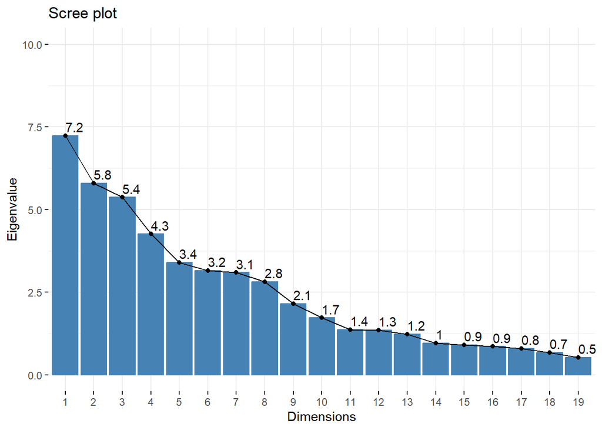

#### Confusion Matrix on test data

Using the Scree Plot to determine the numebr of components to use, 14, a model is made and predictions are made to the testing data set.

```
## Call:
## multinom(formula = Result ~ PC1 + PC2 + PC3 + PC4 + PC5 + PC6 +
##     PC7 + PC8 + PC9 + PC10 + PC11 + PC12 + PC13 + PC14, data = trg)
##
## Coefficients:
##                 Values Std. Err.
## (Intercept)  -2.568470  48.85188
## PC1          81.817105 139.31194
## PC2         -56.454374  99.97074
## PC3         -10.546135  13.46377
## PC4           8.347573  37.31583
## PC5          14.432528  99.23502
## PC6           8.674957  99.91611
## PC7           3.121512  42.41532
## PC8         -20.468558  53.05960
## PC9           9.109782  20.63699
## PC10          6.603739  40.49849
## PC11        -20.937730  47.25711
## PC12          7.978906  48.35383
## PC13        -22.311779  31.11478
## PC14         22.987925  68.96926
##
## Residual Deviance: 0.0393966
## AIC: 30.0394
```

The following table shows the number of correct and incorrect predictions.

```
## Confusion Matrix and Statistics
##
##           Reference
## Prediction  0  1
##          0 58  4
##          1  5 50
##
##                Accuracy : 0.9231
##                  95% CI : (0.859, 0.9642)
##     No Information Rate : 0.5385
##     P-Value [Acc > NIR] : <2e-16
##
##                   Kappa : 0.8454
##
##  Mcnemar's Test P-Value : 1
##
##             Sensitivity : 0.9206
##             Specificity : 0.9259
##          Pos Pred Value : 0.9355
##          Neg Pred Value : 0.9091
##              Prevalence : 0.5385
##          Detection Rate : 0.4957
##    Detection Prevalence : 0.5299
##       Balanced Accuracy : 0.9233
##
##        'Positive' Class : 0
##
```

### LASSO

The Least Absolute Shrinkage and Selection Operator technique is a statistical formula that works ideally with data that would benefit from feature reduction. LASSO is an extension of Ordinary Least Squares regression, a regression method that minimizes the Residual Sum of Squares.

The RSS term is a measurement of discrepancies between the feature values, x, and the predicted values y. Here, the tuning parameter λ is what the focus is on. This parameter dictates the amount that a coefficient for a feature will be shrunken down too. The benefit of using this parameter is that it allows the coefficients for variables to be shrunken down to zero and be removed from the final model if the variable has a significantly small influence on the prediction.

Using cross validation on the training data set, a plot of the mis classification error rate is presented. Noticing that the left most dotted vertical line is the minimum lambda and the right one is one standard error away. This tells us how the number of features impacts the misclassification error rate.

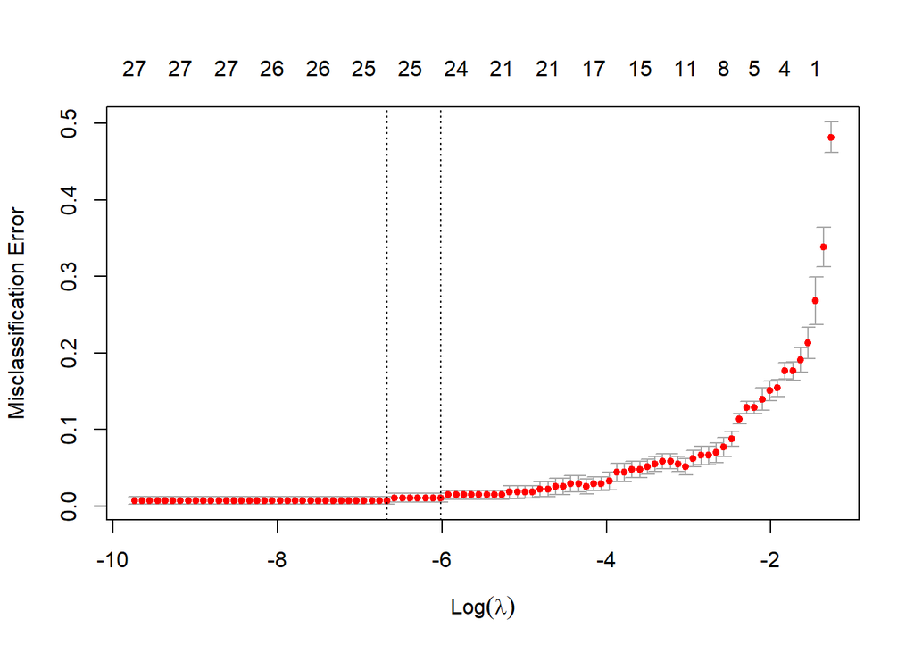

#### Confusion Matrix on test data

Confusion Matrix from the model fitted with training data results applied to the testing data set.

```
## Confusion Matrix and Statistics
##
##           Reference
## Prediction  0  1
##          0 62  1
##          1  1 53
##
##                Accuracy : 0.9829
##                  95% CI : (0.9396, 0.9979)
##     No Information Rate : 0.5385
##     P-Value [Acc > NIR] : <2e-16
##
##                   Kappa : 0.9656
##
##  Mcnemar's Test P-Value : 1
##
##             Sensitivity : 0.9841
##             Specificity : 0.9815
##          Pos Pred Value : 0.9841
##          Neg Pred Value : 0.9815
##              Prevalence : 0.5385
##          Detection Rate : 0.5299
##    Detection Prevalence : 0.5385
##       Balanced Accuracy : 0.9828
##
##        'Positive' Class : 0
##
```

### Stepwise approach

Best subset selection, forward stepwise and backward stepwise selection methods are all feature reduction methods that select features based on the model that produces the best accuracy metrics, Akaike Information Criterion for this case. AIC values are a relative estimator for prediction error for a statistical model. The value itself has no meaning; one statistical model will produce an AIC value. Computing multiple statistical models with the same data set and different features will produce a range of AIC values that estimates the quality of each model as they relate to each other. The lowest AIC value and it’s associated model, the less information the model loses in comparison to other models. Best subset selection calculates the AIC value for every combination possible for a data set. This method can become computationally taxing as the number of explanatory features increases. Forward Stepwise starts with a clean slate, then adding variables one at a time and testing the improvement to the model. Backwards stepwise starts with all features and removes one variable at a time and testing the improvement of the model.

Using subset selection techniques, the following results shows the three method’s AIC values along with the models and features used. The lower the AIC Value the better the comparable model.

*Backward subset methodology*

AIC VALUE

```
## [1] 18
```

MODEL

```
## Result ~ S_FG + O_FGA + O_FT + FTr + O_TPA + S_FG_Per + O_FG_Per +
##     TS_Per
```

*Forward subset methodology*

AIC VALUE

```
## [1] 16.00005
```

MODEL

```
## Result ~ TS_Per + O_FG + DEF_FT_FGA + S_FGA + S_FTA + O_TPA +
##     O_TP_PER
```

*Best subset methodology*

AIC VALUE

```
## [1] 16.00005
```

MODEL

```
## Result ~ TS_Per + O_FG + DEF_FT_FGA + S_FGA + S_FTA + O_TPA +
##     O_TP_PER
```

#### Best Subset - Confusion Matrix on test data

The best subset methodology receives the following results.

```
## Confusion Matrix and Statistics
##
##           Reference
## Prediction  0  1
##          0 62  1
##          1  4 50
##
##                Accuracy : 0.9573
##                  95% CI : (0.9031, 0.986)
##     No Information Rate : 0.5641
##     P-Value [Acc > NIR] : <2e-16
##
##                   Kappa : 0.9137
##
##  Mcnemar's Test P-Value : 0.3711
##
##             Sensitivity : 0.9394
##             Specificity : 0.9804
##          Pos Pred Value : 0.9841
##          Neg Pred Value : 0.9259
##              Prevalence : 0.5641
##          Detection Rate : 0.5299
##    Detection Prevalence : 0.5385
##       Balanced Accuracy : 0.9599
##
##        'Positive' Class : 0
##
```

#### Backwards Stepwise - Confusion Matrix on test data

The backwards subset methodology receives the following results.

```
## Confusion Matrix and Statistics
##
##           Reference
## Prediction  0  1
##          0 59  4
##          1  2 52
##
##                Accuracy : 0.9487
##                  95% CI : (0.8917, 0.981)
##     No Information Rate : 0.5214
##     P-Value [Acc > NIR] : <2e-16
##
##                   Kappa : 0.8971
##
##  Mcnemar's Test P-Value : 0.6831
##
##             Sensitivity : 0.9672
##             Specificity : 0.9286
##          Pos Pred Value : 0.9365
##          Neg Pred Value : 0.9630
##              Prevalence : 0.5214
##          Detection Rate : 0.5043
##    Detection Prevalence : 0.5385
##       Balanced Accuracy : 0.9479
##
##        'Positive' Class : 0
##
```

#### Forward Stepwise - Confusion Matrix on test data

The forward subset methodology receives the following results.

```
## Confusion Matrix and Statistics
##
##           Reference
## Prediction  0  1
##          0 62  1
##          1  4 50
##
##                Accuracy : 0.9573
##                  95% CI : (0.9031, 0.986)
##     No Information Rate : 0.5641
##     P-Value [Acc > NIR] : <2e-16
##
##                   Kappa : 0.9137
##
##  Mcnemar's Test P-Value : 0.3711
##
##             Sensitivity : 0.9394
##             Specificity : 0.9804
##          Pos Pred Value : 0.9841
##          Neg Pred Value : 0.9259
##              Prevalence : 0.5641
##          Detection Rate : 0.5299
##    Detection Prevalence : 0.5385
##       Balanced Accuracy : 0.9599
##
##        'Positive' Class : 0
##
```

### Decision Tree

Classification trees intends to segment the predictor space into a small set of interpretable regions. It does this by implementing recursive binary splitting to grow the tree using the classification error rate as a criterion to split the tree. What does this mean exactly? To find the first split, all predictors are tested and the one with the greatest reduction in classification error rate is chosen to be the root node. This process does not care what will happen down the line at a future split, only what predictors are available. The tree stops when there is a homogeneous class remaining and the tree is considered 100% pure.

```
##
## Classification tree:
## tree(formula = Result ~ ., data = train.dat)
## Variables actually used in tree construction:
##  [1] "TS_Per"      "O_FG"        "OFF_TOV_Per" "O_FTA"       "S_TRB"
##  [6] "O_ORB"       "O_FG_Per"    "STL_Per"     "TRB_Per"     "DEF_TOV_Per"
## [11] "S_AST"       "S_FT"        "O_FT"
## Number of terminal nodes:  17
## Residual mean deviance:  0.1796 = 45.79 / 255
## Misclassification error rate: 0.03676 = 10 / 272
```

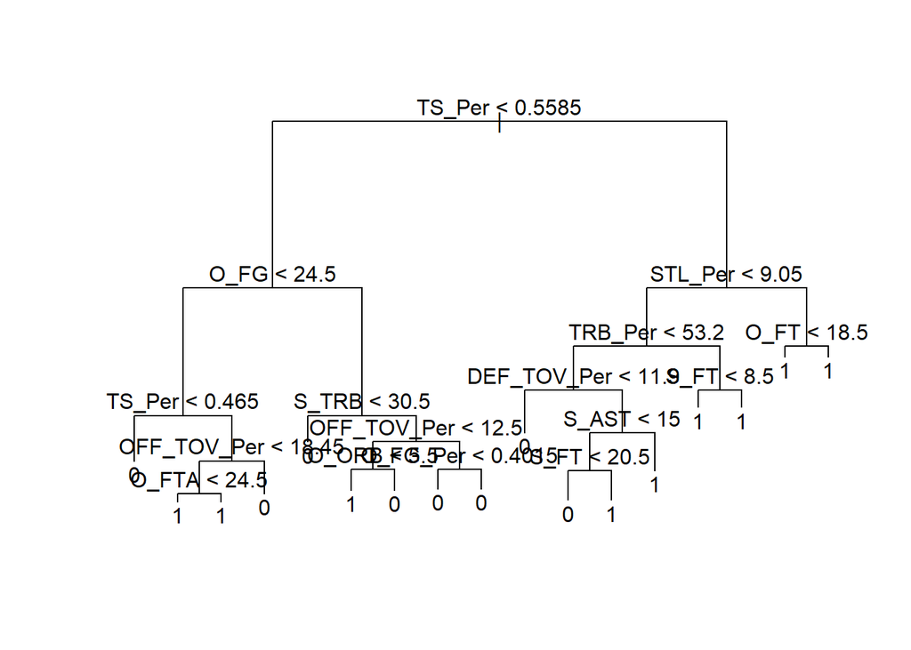

#### Decision Tree - Confusion Matrix on test data

```
##
## tree.bsu1  0  1
##         0 48  7
##         1 15 47
```

```
## Confusion Matrix and Statistics
##
##           Reference
## Prediction  0  1
##          0 48  7
##          1 15 47
##
##                Accuracy : 0.812
##                  95% CI : (0.7293, 0.8782)
##     No Information Rate : 0.5385
##     P-Value [Acc > NIR] : 5.474e-10
##
##                   Kappa : 0.6257
##
##  Mcnemar's Test P-Value : 0.1356
##
##             Sensitivity : 0.7619
##             Specificity : 0.8704
##          Pos Pred Value : 0.8727
##          Neg Pred Value : 0.7581
##              Prevalence : 0.5385
##          Detection Rate : 0.4103
##    Detection Prevalence : 0.4701
##       Balanced Accuracy : 0.8161
##
##        'Positive' Class : 0
##
```

```
##
## Classification tree:
## snip.tree(tree = tree.bsu, nodes = c(7L, 13L, 5L, 9L, 50L))
## Variables actually used in tree construction:
## [1] "TS_Per"      "O_FG"        "STL_Per"     "TRB_Per"     "DEF_TOV_Per"
## [6] "S_AST"
## Number of terminal nodes:  8
## Residual mean deviance:  0.5112 = 135 / 264
## Misclassification error rate: 0.08088 = 22 / 272
```

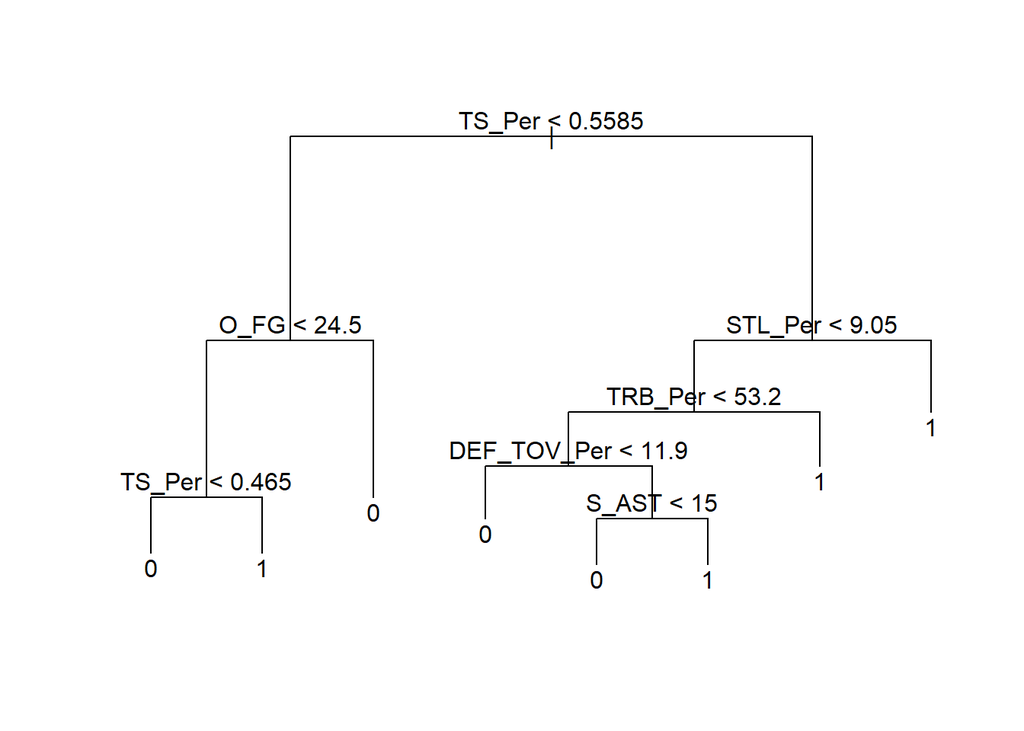

#### Pruned Tree - Confusion Matrix on test data

```
## Confusion Matrix and Statistics
##
##           Reference
## Prediction  0  1
##          0 47  6
##          1 16 48
##
##                Accuracy : 0.812
##                  95% CI : (0.7293, 0.8782)
##     No Information Rate : 0.5385
##     P-Value [Acc > NIR] : 5.474e-10
##
##                   Kappa : 0.6266
##
##  Mcnemar's Test P-Value : 0.05501
##
##             Sensitivity : 0.7460
##             Specificity : 0.8889
##          Pos Pred Value : 0.8868
##          Neg Pred Value : 0.7500
##              Prevalence : 0.5385
##          Detection Rate : 0.4017
##    Detection Prevalence : 0.4530
##       Balanced Accuracy : 0.8175
##
##        'Positive' Class : 0
##
```

## Results

*The following table shows the frequency of each feature used in the models*

| variables | n |
| --- | --- |
| TS_Per | 6 |
| O_FG | 5 |
| DEF_TOV_Per | 3 |
| O_FT | 3 |
| O_TP_PER | 3 |
| O_TPA | 3 |
| DEF_FT_FGA | 2 |
| O_FG_Per | 2 |
| O_FTA | 2 |
| OFF_TOV_Per | 2 |

[output cut: 27 more lines]

*The following table shows what features each technique used*

|  | Pruned_Tree | Decision_Tree | Two_Directional | Backwards_Stepwise | Forward_Stepwise | LASSO |
| --- | --- | --- | --- | --- | --- | --- |
| 1 | DEF_TOV_Per | DEF_TOV_Per | TS_Per | FTr | DEF_FT_FGA | AST_Per |
| 2 | O_FG | O_FG | O_FG | O_FG_Per | O_FG | BLK_Per |
| 3 | S_AST | O_FG_Per | DEF_FT_FGA | O_FGA | O_TP_PER | DEF_eFG_Per |
| 4 | STL_Per | O_FT | S_FGA | O_FT | O_TPA | DEF_TOV_Per |
| 5 | TRB_Per | O_FTA | S_FTA | O_TPA | S_FGA | Location |
| 6 | TS_Per | O_ORB | O_TPA | S_FG | S_FTA | O_BLK |
| 7 | NA | OFF_TOV_Per | O_TP_PER | S_FG_Per | TS_Per | O_FG |
| 8 | NA | S_AST | NA | TS_Per | NA | O_FT |
| 9 | NA | S_FT | NA | NA | NA | O_FTA |
| 10 | NA | S_TRB | NA | NA | NA | O_PF |

[output cut: 14 more lines]

*The following shows which observations, games, the models couldn’t predict, along with the frequency of each*

| Obs | n |
| --- | --- |
| 81 | 7 |
| 8 | 4 |
| 53 | 4 |
| 56 | 4 |
| 18 | 3 |
| 55 | 3 |
| 61 | 3 |
| 76 | 3 |
| 107 | 3 |
| 1 | 2 |

[output cut: 21 more lines]

|  | Test Error | Misclassified | Features Used |
| --- | --- | --- | --- |
| Pruned Tree | 0.1880342 | 22 | 6 |
| Decision Tree | 0.1880342 | 22 | 13 |
| Best Subset | 0.0427350 | 5 | 7 |
| Backwards Stepwise | 0.0512821 | 6 | 8 |
| Forward Stepwise | 0.0427350 | 5 | 7 |
| LASSO | 0.0170940 | 2 | 24 |
| PCA | 0.0769231 | 9 | 14 |